# Self-Driving Car Engineer Nanodegree

## Project: Build a Traffic Sign Recognition Classifier

In this notebook, a template is provided for you to implement your functionality in stages, which is required to successfully complete this project. If additional code is required that cannot be included in the notebook, be sure that the Python code is successfully imported and included in your submission if necessary.

In addition to implementing code, there is a writeup to complete. The writeup should be completed in a separate file, which can be either a markdown file or a pdf document. There is a [write up template](https://github.com/udacity/CarND-Traffic-Sign-Classifier-Project/blob/master/writeup_template.md) that can be used to guide the writing process. Completing the code template and writeup template will cover all of the [rubric points](https://review.udacity.com/#!/rubrics/481/view) for this project.

The [rubric](https://review.udacity.com/#!/rubrics/481/view) contains "Stand Out Suggestions" for enhancing the project beyond the minimum requirements. The stand out suggestions are optional. If you decide to pursue the "stand out suggestions", you can include the code in this Ipython notebook and also discuss the results in the writeup file.

> **Note:** Code and Markdown cells can be executed using the **Shift + Enter** keyboard shortcut. In addition, Markdown cells can be edited by typically double-clicking the cell to enter edit mode.

## Step 0: Load The Data

```python
# Import
import pickle
import pandas as pd
import numpy as np
import random
from random import randint
import cv2
import glob
import tensorflow as tf
import matplotlib.pyplot as plt
import matplotlib.gridspec as gs
from scipy import ndimage
import gc
from PIL import ImageEnhance
from PIL import Image
from tqdm import tqdm
from skimage import transform as trans
from skimage import img_as_ubyte
from skimage import restoration
from sklearn.utils import shuffle
import warnings
import textwrap
import csv
from tensorflow.contrib.layers import flatten
```

```python
# TODO: Fill this in based on where you saved the training and testing data

training_file = './data/train.p'
validation_file='./data/valid.p'
testing_file = './data/test.p'

with open(training_file, mode='rb') as f:
    train = pickle.load(f)
with open(validation_file, mode='rb') as f:
    valid = pickle.load(f)
with open(testing_file, mode='rb') as f:
    test = pickle.load(f)

X_train, y_train = train['features'], train['labels']
X_valid, y_valid = valid['features'], valid['labels']
X_test, y_test = test['features'], test['labels']

X_train_ori, y_train_ori = train['features'], train['labels']
X_valid_ori, y_valid_ori = valid['features'], valid['labels']
X_test_ori, y_test_ori = test['features'], test['labels']

assert(len(X_train) == len(y_train))
assert(len(X_valid) == len(y_valid))
assert(len(X_test) == len(y_test))

print ("Data Loaded")
```

```
Data Loaded
```

## Step 1: Dataset Summary & Exploration

The pickled data is a dictionary with 4 key/value pairs:

- `'features'` is a 4D array containing raw pixel data of the traffic sign images, (num examples, width, height, channels).
- `'labels'` is a 1D array containing the label/class id of the traffic sign. The file `signnames.csv` contains id -> name mappings for each id.
- `'sizes'` is a list containing tuples, (width, height) representing the original width and height the image.
- `'coords'` is a list containing tuples, (x1, y1, x2, y2) representing coordinates of a bounding box around the sign in the image. **THESE COORDINATES ASSUME THE ORIGINAL IMAGE. THE PICKLED DATA CONTAINS RESIZED VERSIONS (32 by 32) OF THESE IMAGES**

Complete the basic data summary below. Use python, numpy and/or pandas methods to calculate the data summary rather than hard coding the results. For example, the [pandas shape method](http://pandas.pydata.org/pandas-docs/stable/generated/pandas.DataFrame.shape.html) might be useful for calculating some of the summary results.

### Provide a Basic Summary of the Data Set Using Python, Numpy and/or Pandas

```python
### Replace each question mark with the appropriate value.
### Use python, pandas or numpy methods rather than hard coding the results

# TODO: Number of training examples
n_train = len(X_train_ori)

# TODO: Number of validation examples
n_validation = len(X_valid_ori)

# TODO: Number of testing examples.
n_test = len(X_test_ori)

# TODO: What's the shape of an traffic sign image?
image_shape = X_train_ori[0].shape

# TODO: How many unique classes/labels there are in the dataset.
n_classes = len(np.unique(y_train_ori))

print("Number of training examples =", n_train)
print("Number of validation examples =", n_validation)
print("Number of testing examples =", n_test)
print("Image data shape =", image_shape)
print("Number of classes =", n_classes)
```

```
Number of training examples = 34799
Number of validation examples = 4410
Number of testing examples = 12630
Image data shape = (32, 32, 3)
Number of classes = 43
```

### Include an exploratory visualization of the dataset

Visualize the German Traffic Signs Dataset using the pickled file(s). This is open ended, suggestions include: plotting traffic sign images, plotting the count of each sign, etc.

The [Matplotlib](http://matplotlib.org/) [examples](http://matplotlib.org/examples/index.html) and [gallery](http://matplotlib.org/gallery.html) pages are a great resource for doing visualizations in Python.

**NOTE:** It's recommended you start with something simple first. If you wish to do more, come back to it after you've completed the rest of the sections. It can be interesting to look at the distribution of classes in the training, validation and test set. Is the distribution the same? Are there more examples of some classes than others?

```python
### Data exploration visualization code goes here.
### Feel free to use as many code cells as needed.
import matplotlib.pyplot as plt
# Visualizations will be shown in the notebook.
%matplotlib inline
```

```python
label_keys = None
with open('signnames.csv', mode='r') as infile:
    r = csv.reader(infile)
    next(r, None)
    label_keys = {int(rows[0]):rows[1] for rows in r}


def plotGrid(sample_set, labels,  signnames, name, columns=5, cutoff = 5):
    assert len(sample_set) == len(labels)
    input_set = sample_set[labels.argsort()]
    classes, counts = np.unique(labels, return_counts=True)
    indexes = np.append([0],np.cumsum(counts))
    figsize = (3*columns,3*(min(len(classes),cutoff)))
    fig, axes = plt.subplots(min(len(classes),cutoff), columns,figsize=figsize)
    fig.subplots_adjust(hspace=0, wspace=0)
    for i, row in enumerate(axes):
        index = list(range(indexes[i], indexes[i+1]))
        random.shuffle(index)
        for j,ax in enumerate(row):
            if (len(index)>0):
                ind = index.pop()
                if input_set[ind].shape[2]<3:
                    ax.imshow(input_set[ind][:,:,0], cmap='gray')
                else:
                    ax.imshow(input_set[ind])
                if j == 0:
                    ax.set_ylabel(textwrap.fill(signnames[classes[i]],15),rotation=0, fontsize=20, horizontalalignment =  'right')
            ax.get_xaxis().set_ticks([])
            ax.get_yaxis().set_ticks([])
```

## Visualizing Dataset

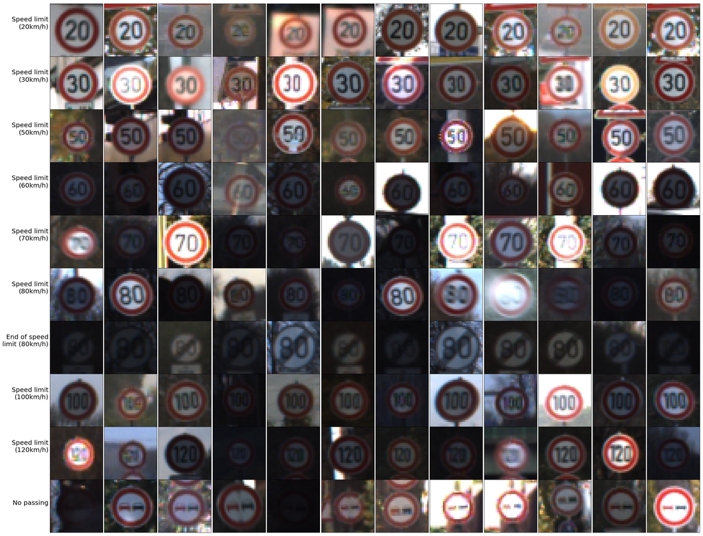

```python
plotGrid(X_train_ori,y_train_ori,label_keys,'raw_visualization',12,10)
```

```python
def show_lable_distribution(y):


    y_train_df = pd.DataFrame()
    y_train_df['label'] = y
    ax = y_train_df['label'].value_counts().plot(kind='barh', figsize = (10,10), title='Samples per Class')
    ax.set_yticklabels(list(map(lambda x: label_keys[x], y_train_df['label'].value_counts().index.tolist())))
    for i, v in enumerate(y_train_df['label'].value_counts()):
        ax.text(v + 10, i - 0.25, str(v), color='red')
```

```
Original distribution
```

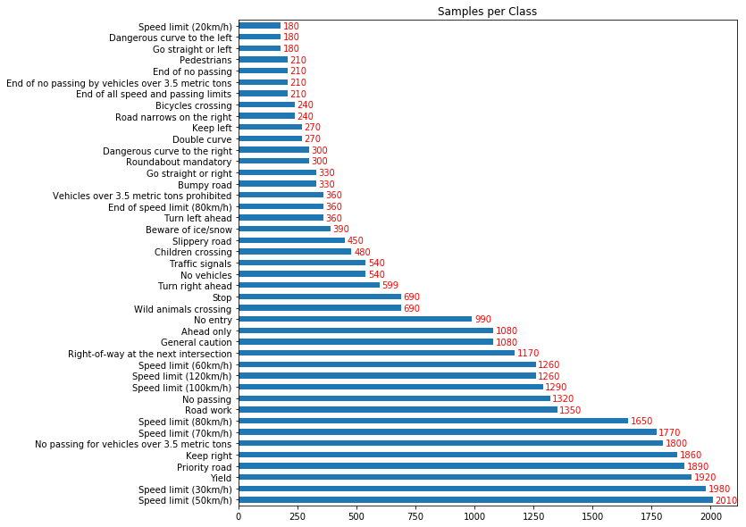

```python
print("Original distribution")
show_lable_distribution(y_train)
```

## Step 2: Design and Test a Model Architecture

Design and implement a deep learning model that learns to recognize traffic signs. Train and test your model on the [German Traffic Sign Dataset](http://benchmark.ini.rub.de/?section=gtsrb&subsection=dataset).

The LeNet-5 implementation shown in the classroom at the end of the CNN lesson is a solid starting point. You'll have to change the number of classes and possibly the preprocessing, but aside from that it's plug and play!

With the LeNet-5 solution from the lecture, you should expect a validation set accuracy of about 0.89. To meet specifications, the validation set accuracy will need to be at least 0.93. It is possible to get an even higher accuracy, but 0.93 is the minimum for a successful project submission.

There are various aspects to consider when thinking about this problem:

- Neural network architecture (is the network over or underfitting?)
- Play around preprocessing techniques (normalization, rgb to grayscale, etc)
- Number of examples per label (some have more than others).
- Generate fake data.

Here is an example of a [published baseline model on this problem](http://yann.lecun.com/exdb/publis/pdf/sermanet-ijcnn-11.pdf). It's not required to be familiar with the approach used in the paper but, it's good practice to try to read papers like these.

### Pre-process the Data Set (normalization, grayscale, etc.)

Minimally, the image data should be normalized so that the data has mean zero and equal variance. For image data, `(pixel - 128)/ 128` is a quick way to approximately normalize the data and can be used in this project.

Other pre-processing steps are optional. You can try different techniques to see if it improves performance.

Use the code cell (or multiple code cells, if necessary) to implement the first step of your project.

## Preprocess

```python
import random
import numpy as np
import cv2
from sklearn.utils import shuffle


def clahe(image):
    ### Contrast Limited Adaptive Histogram Equalization
    ### http://docs.opencv.org/3.1.0/d5/daf/tutorial_py_histogram_equalization.html

    img_lab= cv2.cvtColor(image, cv2.COLOR_BGR2LAB)
    img = img_lab[:,:,0]
    clahe = cv2.createCLAHE(clipLimit=5.0, tileGridSize=(4,4))
    cl = clahe.apply(img)
    img_lab[:,:,0] = cl
    img =  cv2.cvtColor(img_lab, cv2.COLOR_LAB2BGR)
    new_img = np.zeros(image.shape)
    return img

def normalization(input,l=0.1,u=0.9):
    "squeezes the data between the range given"
    output = np.zeros_like(input, dtype = np.float)
    c=(u-l)
    r = input[:,:,0]
    g = input[:,:,1]
    b = input[:,:,2]
    max_array = np.full(r.shape,u)
    r = l + (r-np.min(r))/(np.max(r)-np.min(r))*(c)
    g = l + (g-np.min(g))/(np.max(g)-np.min(g))*(c)
    b = l + (b-np.min(b))/(np.max(b)-np.min(b))*(c)
    #if a zero division is encountered the nan value is replace by the upper value (u)
    output[:,:,0] = np.where(np.isnan(r),max_array,r)
    output[:,:,1] = np.where(np.isnan(g),max_array,g)
    output[:,:,2] = np.where(np.isnan(b),max_array,b)
    return output

def crop(input) :
#     scale_fac = np.random.normal(1.1,.1)
    scale_fac = 1.25 # Crop Factor
    x_scale=scale_fac
    y_scale=scale_fac
    r,c = input.shape[:-1]
    scaled_img = cv2.resize(input,None,fx=x_scale,fy=y_scale)
    new_img = cv2.copyMakeBorder(scaled_img,5,5,5,5,cv2.BORDER_REPLICATE)
    rows,cols = new_img.shape[:-1]
    r0,c0 = round((rows-r)/2), round((cols-c)/2)
    modified = new_img[r0:r0+r, c0:c0+c]

    return modified
```

## Preprocessing Sanity Check

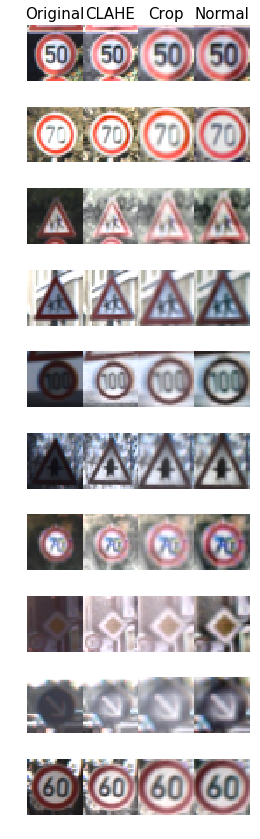

```python
fig, ax = plt.subplots(10,4, figsize=(4,15))
fig.subplots_adjust(hspace=0, wspace=0)
ax[0][0].set_title('Original', fontsize=15)
ax[0][1].set_title('CLAHE', fontsize=15)
ax[0][2].set_title('Crop', fontsize=15)
ax[0][3].set_title('Normal', fontsize=15)
for i in range(10) :
    img = X_train[randint(0,34700)]
    ax[i,0].imshow(img)
    ax[i,1].imshow(clahe(img))
    ax[i,2].imshow(crop(clahe(img)))
    ax[i,3].imshow(normalization(crop(clahe(img))))
for axes in ax.flatten() :
    axes.axis('off')
```

## Augmentation

```python
def scale(input,args) :
    scale_fac = np.random.normal(1.05,.1)
#     scale_fac = 1.1
    x_scale=scale_fac
    y_scale=scale_fac
    r,c = input.shape[:-1]
    scaled_img = cv2.resize(input,None,fx=x_scale,fy=y_scale)
    new_img = cv2.copyMakeBorder(scaled_img,5,5,5,5,cv2.BORDER_REPLICATE)
    rows,cols = new_img.shape[:-1]
    r0,c0 = round((rows-r)/2), round((cols-c)/2)
    modified = new_img[r0:r0+r, c0:c0+c]
    output = img_as_ubyte(modified)
    return [output]

def rotate(input,args):
    theta= np.random.uniform(-15,15) # Rotation bounds
    r,c = input.shape[:-1]
    new_img = cv2.copyMakeBorder(input,5,5,5,5,cv2.BORDER_REPLICATE)
    rows,cols = new_img.shape[:-1]
    M = cv2.getRotationMatrix2D((cols/2,rows/2), theta, 1)
    new_img = cv2.warpAffine(new_img,M,(cols,rows))
    r0,c0 = round((rows-r)/2), round((cols-c)/2)
    modified = new_img[r0:r0+r, c0:c0+c]
    output = img_as_ubyte(modified)
    return [output]

def translate(input,args):
    delta_x= randint(-3,3) # Translation Range
    delta_y= randint(-3,3)
    r,c = input.shape[:-1]
    new_img = cv2.copyMakeBorder(input,5,5,5,5,cv2.BORDER_REPLICATE)
    rows,cols = new_img.shape[:-1]
    r0,c0 = round((rows-r)/2)+ delta_y, round((cols-c)/2)- delta_x
    modified = new_img[r0:r0+r, c0:c0+c]
    output = img_as_ubyte(modified)
    return [output]

def transform_augmentation(input, args):
    shear = np.random.normal(0,.07)
    rotator = np.random.normal(0,.07)
    affine_tf = trans.AffineTransform(shear = shear, rotation = rotator)
    modified = trans.warp(input,affine_tf, mode = args['mode'])
    output = img_as_ubyte(modified)
    return [output]


def perspective_augmentation(input, args):
    m = input.shape[0]
    d = random.choice([random.randint(-6,-1),random.randint(1,6)])
    src = np.float32([[0,0],[0,m],[m,0],[m,m]])
    vertical = np.float32([[d,0],[-d,m],[m-d,0],[m+d,m]])
    horizontal = np.float32([[0,d],[0,m-d],[m,-d],[m,m+d]])
    dst = random.choice([vertical,horizontal])
    tform = cv2.getPerspectiveTransform(src,dst)
    modified = cv2.warpPerspective(input, tform, (32,32), borderMode = cv2.BORDER_REPLICATE)
    output = img_as_ubyte(modified)
    return [output]

def add_noise(input, args):
    output = input.copy()
    x = np.random.randint(0,input.shape[0], args['destroy_intensity'])
    y = np.random.randint(0,input.shape[1], args['destroy_intensity'])
    for j in range(args['destroy_intensity']):
        output[x[j]][y[j]] = np.random.normal(np.median(input),1)
    return [output]

def augment_data(sample_set, labels_set, expansion_size, functions,args):
    sample_set = sample_set[labels_set.argsort()]
    classes, counts = np.unique(labels_set, return_counts=True)
    indexes = np.append([0],np.cumsum(counts))
    samples = sample_set.copy()
    labels =  np.sort(labels_set.copy())
    for i in tqdm(range(n_classes)):
        new_data = np.empty((0,)+sample_set.shape[1:], dtype = sample_set.dtype)
        while new_data.shape[0]<expansion_size:
            index = random.randint(indexes[i],indexes[i+1]-1)
            args['label'] = i
            temp_data = random.choice(functions)(sample_set[index],args)
            new_data  = np.append(new_data,temp_data,axis=0)
        samples = np.append(samples,new_data,axis=0)
        labels = np.append(labels, [i]*new_data.shape[0])
        del new_data
        gc.collect()
    return [samples,labels]

def balance_data(sample_set, labels_set, cutoff=2000):
    """Randomly select data from a set in order to get a equal size balanced data."""
    sample_set = sample_set[labels_set.argsort()]
    classes, counts = np.unique(labels_set, return_counts=True)
    indexes = np.append([0],np.cumsum(counts))
    x_balanced = np.empty((0,)+sample_set.shape[1:], dtype = sample_set.dtype)
    y_balanced = np.empty((0))
    for i in tqdm(range(n_classes)):
        idxs = np.random.randint(indexes[i],indexes[i+1]-1,cutoff)
        temp_data = sample_set[idxs]
        x_balanced = np.append(x_balanced,temp_data,axis=0)
        y_balanced = np.append(y_balanced,[i]*temp_data.shape[0])
    return {'x':x_balanced,'y': y_balanced}
```

## Augmentation Sanity Check

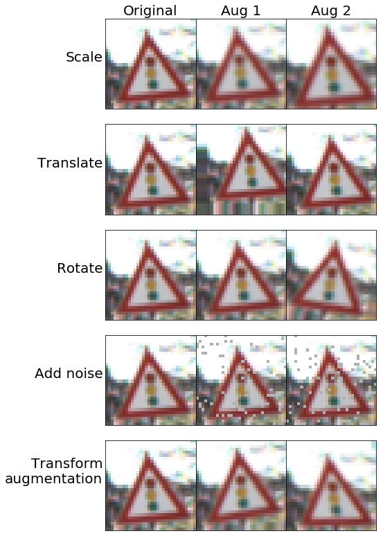

```python
i = 1427
original = X_train_ori[i]
fig, axes = plt.subplots(5,3, figsize = (7,14))
fig.subplots_adjust(hspace=0, wspace=0)
augmentations = [scale,translate,rotate,add_noise,transform_augmentation,perspective_augmentation]
aug_labels = ['Scale','Translate','Rotate','Add noise','Transform augmentation','Perspective augmentation']
args = {'mode':'edge',
        'destroy_intensity':80,
        'label':1}
axes[0][0].set_title('Original', fontsize=20)
axes[0][1].set_title('Aug 1', fontsize=20)
axes[0][2].set_title('Aug 2', fontsize=20)
for i, row in enumerate(axes):
    for j,ax in enumerate(row):
        ax.get_xaxis().set_ticks([])
        ax.get_yaxis().set_ticks([])
        if j % 5 == 0:
            ax.imshow(original)
            ax.set_ylabel(textwrap.fill(aug_labels[i],15),rotation=0, fontsize=20, horizontalalignment =  'right')
        else:
            ax.imshow(augmentations[i](original,args)[0])

plt.show()
# fig.savefig(images_dir+'augmentations_examples.png')
```

## Applying Augmentation

```python
force_data_augmentation = True
#functions use to augment data
functions=[translate,rotate,add_noise,transform_augmentation,perspective_augmentation]
#parameters use to augmetn data
args = {'mode':'edge',
        'destroy_intensity':30}

def augmentation_process(extension=3000,cutoff=3000):
    """perform the augmentation process follow by a balance process"""
    x,y = augment_data(X_train,y_train, extension,functions,args)
    new_data = balance_data(x,y,cutoff)
    pickle.dump(new_data, open('new_data.p','wb'))
    return new_data

if force_data_augmentation:
    new_data = augmentation_process()
else:
    try:
        new_data = pickle.load(open('new_data.p','rb'))
    except(OSError, IOError) as e:
        new_data = augmentation_process()
```

[output not shown]

```python
# Load augmented data
new_data_file = 'new_data.p'


with open(new_data_file, mode='rb') as f:
    new_data = pickle.load(f)


print ("New Data Loaded")
```

[output not shown]

```python
# Assigning new augmented data
bypass_augmentation = False
if bypass_augmentation:
    print("Data not Augmented")
else:
    X_train = new_data['x']
    y_train = new_data['y']
    n_train = X_train.shape[0]
print("New Number of training examples =\t", n_train)
```

```
New Number of training examples =	 129000
```

## Apply Preprocessing

```python
#Step1: ClAHE
X_train = np.asarray([clahe(m) for m in X_train])
X_valid = np.asarray([clahe(m) for m in X_valid])
X_test = np.asarray([clahe(m) for m in X_test])
print ("CLAHE Done")
#Step2: Crop
X_train = np.asarray([crop(m) for m in X_train])
X_valid = np.asarray([crop(m) for m in X_valid])
X_test = np.asarray([crop(m) for m in X_test])
print ("Crop Done")
X_train = np.asarray([normalization(m) for m in X_train])
X_valid = np.asarray([normalization(m) for m in X_valid])
X_test = np.asarray([normalization(m) for m in X_test])
print ("Normalisation Done")
```

```
CLAHE Done
Crop Done
Normalisation Done
```

```
New distribution
```

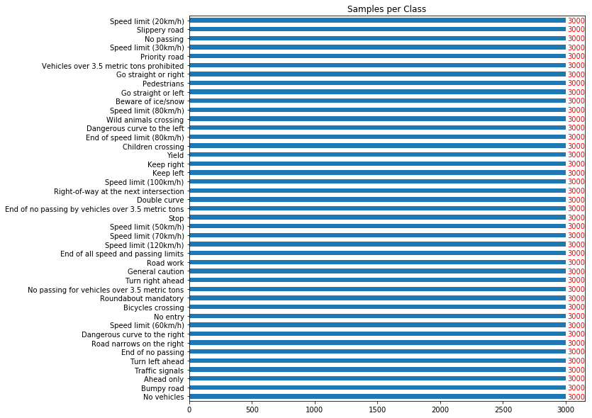

```python
print("New distribution")
show_lable_distribution(y_train)
# fig.savefig(images_dir + 'balanced_training_distribution.png')
```

## Visualizing Augmented and Normalised data

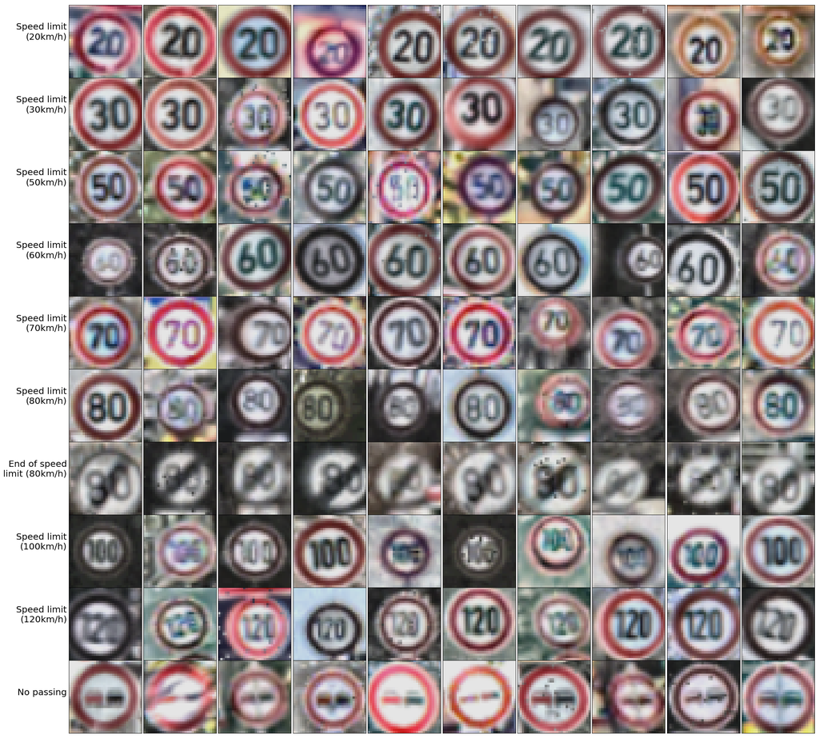

```python
plotGrid(X_train,y_train,label_keys,'raw_visualization',10,10)
```

## Shuffle the data

To prevent similar images from being in the same batch

```python
X_train, y_train = shuffle(X_train, y_train)
```

## VGG Net

```python
def VGGnet(self, n_out=43, mu=0, sigma=0.1, learning_rate=0.0008) :
    # Hyperparameters
    mu = mu
    sigma = sigma

    # Layer 1: Convolutional. Input = 32x32x3. Output = 32x32x32.
    conv1_W = tf.Variable(tf.truncated_normal(shape=(3, 3, 3, 32), mean = mu, stddev = sigma))
    conv1_b = tf.Variable(tf.zeros(32))
    conv1   = tf.nn.conv2d(x, conv1_W, strides=[1, 1, 1, 1], padding='SAME') + conv1_b

    # ReLu Activation.
    conv1 = tf.nn.relu(conv1, name='conv1')

    # Layer 2: Convolutional. Input = 32x32x32. Output = 32x32x32.
    conv2_W = tf.Variable(tf.truncated_normal(shape=(3, 3, 32, 32), mean = mu, stddev = sigma))
    conv2_b = tf.Variable(tf.zeros(32))
    conv2   = tf.nn.conv2d(conv1, conv2_W, strides=[1, 1, 1, 1], padding='SAME') + conv2_b

    # ReLu Activation.
    conv2 = tf.nn.relu(conv2, name='conv2')

    # Pooling. Input = 32x32x32. Output = 16x16x32.
    conv2 = tf.nn.max_pool(conv2, ksize=[1, 2, 2, 1], strides=[1, 2, 2, 1], padding='VALID')
    conv2 = tf.nn.dropout(conv2, keep_prob_conv) # dropout

    # Layer 3: Convolutional. Input = 16x16x32. Output = 16x16x64.
    conv3_W = tf.Variable(tf.truncated_normal(shape=(3, 3, 32, 64), mean = mu, stddev = sigma))
    conv3_b = tf.Variable(tf.zeros(64))
    conv3   = tf.nn.conv2d(conv2, conv3_W, strides=[1, 1, 1, 1], padding='SAME') + conv3_b

    # ReLu Activation.
    conv3 = tf.nn.relu(conv3, name='conv3')

    # Layer 4: Convolutional. Input = 16x16x32. Output = 16x16x64.
    conv4_W = tf.Variable(tf.truncated_normal(shape=(3, 3, 64, 64), mean = mu, stddev = sigma))
    conv4_b = tf.Variable(tf.zeros(64))
    conv4   = tf.nn.conv2d(conv3, conv4_W, strides=[1, 1, 1, 1], padding='SAME') + conv4_b

    # ReLu Activation.
    conv4 = tf.nn.relu(conv4, name='conv4')

    # Pooling. Input = 16x16x64. Output = 8x8x64.
    conv4 = tf.nn.max_pool(conv4, ksize=[1, 2, 2, 1], strides=[1, 2, 2, 1], padding='VALID')
    conv4 = tf.nn.dropout(conv4, keep_prob_conv) # dropout

    # Layer 5: Convolutional. Input = 8x8x64. Output = 8x8x128.
    conv5_W = tf.Variable(tf.truncated_normal(shape=(3, 3, 64, 128), mean = mu, stddev = sigma))
    conv5_b = tf.Variable(tf.zeros(128))
    conv5   = tf.nn.conv2d(conv4, conv5_W, strides=[1, 1, 1, 1], padding='SAME') + conv5_b

    # ReLu Activation.
    conv5 = tf.nn.relu(conv5, name='conv5')

    # Layer 6: Convolutional. Input = 8x8x128. Output = 8x8x128.
    conv6_W = tf.Variable(tf.truncated_normal(shape=(3, 3, 128, 128), mean = mu, stddev = sigma))
    conv6_b = tf.Variable(tf.zeros(128))
    conv6   = tf.nn.conv2d(conv5, conv6_W, strides=[1, 1, 1, 1], padding='SAME') + conv6_b

    # ReLu Activation.
    conv6 = tf.nn.relu(conv6, name='conv6')

    # Pooling. Input = 8x8x128. Output = 4x4x128.
    conv6 = tf.nn.max_pool(conv6, ksize=[1, 2, 2, 1], strides=[1, 2, 2, 1], padding='VALID')
    conv6 = tf.nn.dropout(conv6, keep_prob_conv) # dropout

    # Flatten. Input = 4x4x128. Output = 2048.
    fc0   = flatten(conv6)

    # Layer 7: Fully Connected. Input = 2048. Output = 128.
    fc1_W = tf.Variable(tf.truncated_normal(shape=(2048, 128), mean = mu, stddev = sigma))
    fc1_b = tf.Variable(tf.zeros(128))
    fc1   = tf.matmul(fc0, fc1_W) + fc1_b

    # ReLu Activation.
    fc1    = tf.nn.relu(fc1, name='fc1')
    fc1    = tf.nn.dropout(fc1, keep_prob) # dropout

    # Layer 8: Fully Connected. Input = 128. Output = 128.
    fc2_W  = tf.Variable(tf.truncated_normal(shape=(128, 128), mean = mu, stddev = sigma))
    fc2_b  = tf.Variable(tf.zeros(128))
    fc2    = tf.matmul(fc1, fc2_W) + fc2_b

    # ReLu Activation.
    fc2    = tf.nn.relu(fc2, name='fc2')
    fc2    = tf.nn.dropout(fc2, keep_prob) # dropout

    # Layer 9: Fully Connected. Input = 128. Output = n_out.
    fc3_W  = tf.Variable(tf.truncated_normal(shape=(128, n_out), mean = mu, stddev = sigma))
    fc3_b  = tf.Variable(tf.zeros(n_out))
    logits = tf.matmul(fc2, fc3_W) + fc3_b

    return logits
```

## Modified Lenet with 3 Conv Layers and Dropout

```python
def LeNet3_dp(x):
    # Arguments used for tf.truncated_normal, randomly defines variables for the weights and biases for each layer
    mu = 0
    sigma = 0.1

    # SOLUTION: Layer 1: Convolutional. Input = 32x32x3. Output = 28x28x6.
    conv1_W = tf.Variable(tf.truncated_normal(shape=(5, 5, 3, 6), mean = mu, stddev = sigma))
    conv1_b = tf.Variable(tf.zeros(6))
    conv1   = tf.nn.conv2d(x, conv1_W, strides=[1, 1, 1, 1], padding='VALID') + conv1_b

    # SOLUTION: Activation.
    conv1 = tf.nn.relu(conv1)

    # SOLUTION: Pooling. Input = 28x28x6. Output = 14x14x6.
    conv1 = tf.nn.max_pool(conv1, ksize=[1, 2, 2, 1], strides=[1, 2, 2, 1], padding='VALID')


    # SOLUTION: Layer 2: Convolutional. Output = 12x12x16.
    conv2_W = tf.Variable(tf.truncated_normal(shape=(3, 3, 6, 16), mean = mu, stddev = sigma))
    conv2_b = tf.Variable(tf.zeros(16))
    conv2   = tf.nn.conv2d(conv1, conv2_W, strides=[1, 1, 1, 1], padding='VALID') + conv2_b

    # SOLUTION: Activation.
    conv2 = tf.nn.relu(conv2)


    # SOLUTION: Layer 3: Convolutional. Output = 10x10x32.
    conv3_W = tf.Variable(tf.truncated_normal(shape=(3, 3, 16, 32), mean = mu, stddev = sigma))
    conv3_b = tf.Variable(tf.zeros(32))
    conv3   = tf.nn.conv2d(conv2, conv3_W, strides=[1, 1, 1, 1], padding='VALID') + conv3_b

    # SOLUTION: Activation.
    conv3 = tf.nn.relu(conv3)

    # SOLUTION: Pooling. Input = 10x10x32. Output = 5x5x32.
    conv3 = tf.nn.max_pool(conv3, ksize=[1, 2, 2, 1], strides=[1, 2, 2, 1], padding='VALID')

    # SOLUTION: Flatten. Input = 5x5x32. Output = 800.
    fc0   = flatten(conv3)

    # SOLUTION: Layer 3: Fully Connected. Input = 800. Output = 120.
    fc1_W = tf.Variable(tf.truncated_normal(shape=(800, 200), mean = mu, stddev = sigma))
    fc1_b = tf.Variable(tf.zeros(200))
    fc1   = tf.matmul(fc0, fc1_W) + fc1_b

    # SOLUTION: Activation.
    fc1    = tf.nn.relu(fc1)

    # Dropout
    fc1 = tf.nn.dropout(fc1, keep_prob)

    # SOLUTION: Layer 4: Fully Connected. Input = 200. Output = 84.
    fc2_W  = tf.Variable(tf.truncated_normal(shape=(200, 84), mean = mu, stddev = sigma))
    fc2_b  = tf.Variable(tf.zeros(84))
    fc2    = tf.matmul(fc1, fc2_W) + fc2_b

    # SOLUTION: Activation.
    fc2    = tf.nn.relu(fc2)

    # Dropout
    fc2 = tf.nn.dropout(fc2, keep_prob)

    # SOLUTION: Layer 5: Fully Connected. Input = 84. Output = 43.
    fc3_W  = tf.Variable(tf.truncated_normal(shape=(84, 43), mean = mu, stddev = sigma))
    fc3_b  = tf.Variable(tf.zeros(43))
    logits = tf.matmul(fc2, fc3_W) + fc3_b

    return logits
```

```python
keep_prob = tf.placeholder(tf.float32) # for fully-connected layers
keep_prob_conv = tf.placeholder(tf.float32) # for convolutional layers
x = tf.placeholder(tf.float32, (None, 32, 32, 3))
y = tf.placeholder(tf.int32, (None))
one_hot_y = tf.one_hot(y, 43)
```

### Train, Validate and Test the Model

```python
EPOCHS = 30
BATCH_SIZE = 64
rate=0.001
save_file = 'checkpoints/Lenet3dp.ckpt'
```

```python
# Training Pipeline
logits = LeNet3_dp(x)
cross_entropy = tf.nn.softmax_cross_entropy_with_logits(labels=one_hot_y, logits=logits)
loss_operation = tf.reduce_mean(cross_entropy)
optimizer = tf.train.AdamOptimizer(learning_rate = rate)
training_operation = optimizer.minimize(loss_operation)

# Accuracy
correct_prediction = tf.equal(tf.argmax(logits, 1), tf.argmax(one_hot_y, 1))
accuracy_operation = tf.reduce_mean(tf.cast(correct_prediction, tf.float32))

# Save Model
saver = tf.train.Saver()

def evaluate(X_data, y_data):
    num_examples = len(X_data)
    total_accuracy = 0
    sess = tf.get_default_session()
    for offset in range(0, num_examples, BATCH_SIZE):
        batch_x, batch_y = X_data[offset:offset+BATCH_SIZE], y_data[offset:offset+BATCH_SIZE]
        accuracy = sess.run(accuracy_operation, feed_dict={x: batch_x, y: batch_y, keep_prob : 0.5, keep_prob_conv:0.7})
#         accuracy = sess.run(accuracy_operation, feed_dict={x: batch_x, y: batch_y})
        total_accuracy += (accuracy * len(batch_x))
    return total_accuracy / num_examples
```

```python
with tf.Session() as sess:
    sess.run(tf.global_variables_initializer())
    num_examples = len(X_train)

    print("Training...")
    print()
    for i in range(EPOCHS):
        X_train, y_train = shuffle(X_train, y_train)
        for offset in range(0, num_examples, BATCH_SIZE):
            end = offset + BATCH_SIZE
            batch_x, batch_y = X_train[offset:end], y_train[offset:end]
            sess.run(training_operation, feed_dict={x: batch_x, y: batch_y, keep_prob : 0.5, keep_prob_conv:0.7})
#             sess.run(training_operation, feed_dict={x: batch_x, y: batch_y})

        validation_accuracy = evaluate(X_valid, y_valid)
        print("EPOCH {} ...".format(i+1))
        print("Validation Accuracy = {:.3f}".format(validation_accuracy))
        print()

    saver.save(sess,save_file)
    print("Model saved")
```

```
Training...

EPOCH 1 ...
Validation Accuracy = 0.825

EPOCH 2 ...
Validation Accuracy = 0.890

EPOCH 3 ...
Validation Accuracy = 0.917

EPOCH 4 ...
Validation Accuracy = 0.919

EPOCH 5 ...
Validation Accuracy = 0.938

EPOCH 6 ...
Validation Accuracy = 0.949

EPOCH 7 ...
Validation Accuracy = 0.945

EPOCH 8 ...
Validation Accuracy = 0.952

EPOCH 9 ...
Validation Accuracy = 0.949

EPOCH 10 ...
Validation Accuracy = 0.946

EPOCH 11 ...
Validation Accuracy = 0.955

EPOCH 12 ...
Validation Accuracy = 0.957

EPOCH 13 ...
Validation Accuracy = 0.958
```

[output cut: 38 more lines]

```
Validation Accuracy = 0.961

EPOCH 27 ...
Validation Accuracy = 0.957

EPOCH 28 ...
Validation Accuracy = 0.956

EPOCH 29 ...
Validation Accuracy = 0.962

EPOCH 30 ...
Validation Accuracy = 0.959

Model saved
```

```
Test Accuracy = 0.945
incorrectly predicted examples
```

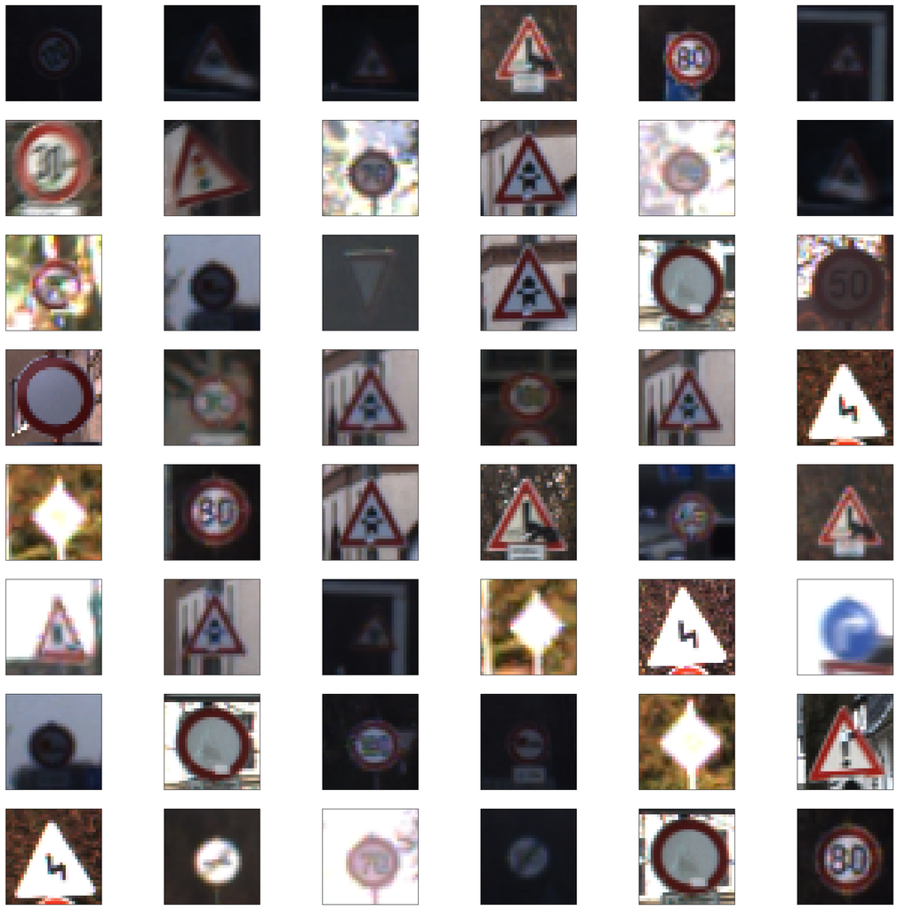

```python
testing_file = 'data/test.p'
with open(testing_file, mode='rb') as f:
    test = pickle.load(f)

X_test_ori = test['features']
y_test_ori = test['labels']
image_shape =(X_train.shape[1],X_train.shape[2])


# Test Accuracy
with tf.Session() as sess:
#     saver.restore(sess, tf.train.latest_checkpoint('.'))
    saver.restore(sess, save_file )
    test_accuracy = evaluate(X_test, y_test)
    print("Test Accuracy = {:.3f}".format(test_accuracy))
    probability, classes = sess.run(tf.nn.top_k(tf.nn.softmax(logits), k = 1), feed_dict={x: X_test, keep_prob: 1.0})
    predicted_classes = np.array([x[0] for x in classes])
    incorrectly_predicted = X_test_ori[predicted_classes != y_test_ori]
    print ("incorrectly predicted examples")
    import matplotlib.pyplot as plt
    # Visualizations will be shown in the notebook.
    %matplotlib inline
    fig, axes = plt.subplots(8, 6, figsize=image_shape,
                         subplot_kw={'xticks': [], 'yticks': []})
    for ax, i in zip(axes.flat,range(0,8*6)):
        ax.imshow(incorrectly_predicted[i].squeeze())

    plt.show()
```

## Visualize Test Set

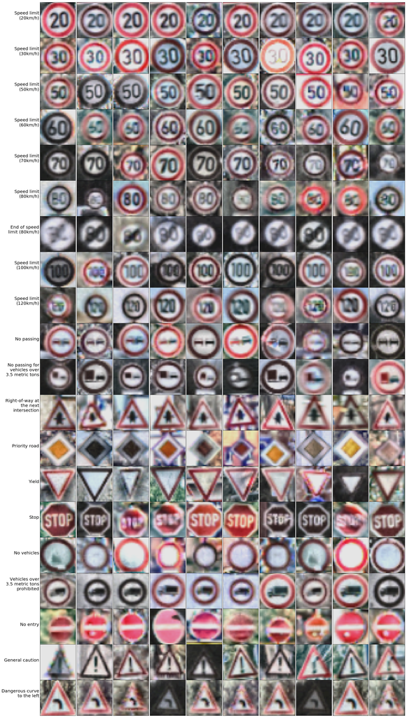

```python
plotGrid(X_test,y_test,label_keys,'raw_visualization',10,20)
```

## Step 3: Test a Model on New Images

To give yourself more insight into how your model is working, download at least five pictures of German traffic signs from the web and use your model to predict the traffic sign type.

You may find `signnames.csv` useful as it contains mappings from the class id (integer) to the actual sign name.

### Load and Output the Images

```
New test images:
Number of test imgs:  6
labels:  ['1' '12' '14' '18' '23' '8']
```

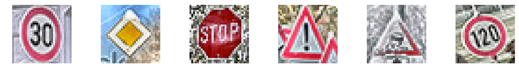

```python
import scipy.ndimage
from glob import glob


print("New test images: ")

test_images = glob('test_imgs/*')
X_ori = []
X_example = []
y_example = []
for img in test_images:
    y_example.append(img.split(".")[0].split("/")[1])
    img_ori = plt.imread(img)
    # Apply Preprocessing
    img = clahe(img_ori)
    img = cv2.resize(img,(32,32))
    X_example.append(img)
    X_ori.append(img_ori)


print ("Number of test imgs: ",len(X_example))
### Visualize the reshaped test traffic signs

fig, axs = plt.subplots(1,6, figsize=(20, 20), facecolor='w', edgecolor='k')
fig.subplots_adjust(hspace = .5, wspace=.5)

axs = axs.ravel()

for i in range(len(axs)):
    axs[i].imshow(X_example[i])


for ax in axs:
    ax.axis('off')

X_example = np.asarray(X_example)
y_example = np.asarray(y_example)
print ("labels: ",y_example)
X_example = X_example.reshape(X_example.shape[0],X_example.shape[1],X_example.shape[2],3)
```

### Predict the Sign Type for Each Image

```python
predictions = None

with tf.Session() as sess:
    saver.restore(sess, save_file)
    sess = tf.get_default_session()
    predictions = sess.run(tf.argmax(logits, 1), feed_dict={x:X_example, keep_prob:1.0})
```

### Analyze Performance

```python
with tf.Session() as sess:
    sess.run(tf.global_variables_initializer())
    saver.restore(sess, save_file)
    test_accuracy = evaluate(X_example, y_example)
    print("Test Accuracy second stage = {:.3f}".format(test_accuracy))
```

```
Test Accuracy second stage = 1.000
```

### Output Top 5 Softmax Probabilities For Each Image Found on the Web

For each of the new images, print out the model's softmax probabilities to show the **certainty** of the model's predictions (limit the output to the top 5 probabilities for each image). [`tf.nn.top_k`](https://www.tensorflow.org/versions/r0.12/api_docs/python/nn.html#top_k) could prove helpful here.

The example below demonstrates how tf.nn.top_k can be used to find the top k predictions for each image.

`tf.nn.top_k` will return the values and indices (class ids) of the top k predictions. So if k=3, for each sign, it'll return the 3 largest probabilities (out of a possible 43) and the correspoding class ids.

Take this numpy array as an example. The values in the array represent predictions. The array contains softmax probabilities for five candidate images with six possible classes. `tk.nn.top_k` is used to choose the three classes with the highest probability:

```
# (5, 6) array
a = np.array([[ 0.24879643,  0.07032244,  0.12641572,  0.34763842,  0.07893497,
         0.12789202],
       [ 0.28086119,  0.27569815,  0.08594638,  0.0178669 ,  0.18063401,
         0.15899337],
       [ 0.26076848,  0.23664738,  0.08020603,  0.07001922,  0.1134371 ,
         0.23892179],
       [ 0.11943333,  0.29198961,  0.02605103,  0.26234032,  0.1351348 ,
         0.16505091],
       [ 0.09561176,  0.34396535,  0.0643941 ,  0.16240774,  0.24206137,
         0.09155967]])
```

Running it through `sess.run(tf.nn.top_k(tf.constant(a), k=3))` produces:

```
TopKV2(values=array([[ 0.34763842,  0.24879643,  0.12789202],
       [ 0.28086119,  0.27569815,  0.18063401],
       [ 0.26076848,  0.23892179,  0.23664738],
       [ 0.29198961,  0.26234032,  0.16505091],
       [ 0.34396535,  0.24206137,  0.16240774]]), indices=array([[3, 0, 5],
       [0, 1, 4],
       [0, 5, 1],
       [1, 3, 5],
       [1, 4, 3]], dtype=int32))
```

Looking just at the first row we get `[ 0.34763842, 0.24879643, 0.12789202]`, you can confirm these are the 3 largest probabilities in `a`. You'll also notice `[3, 0, 5]` are the corresponding indices.

```
Test Accuracy is 100.00%
                      Probability
Sign Name
Speed limit (30km/h)          1.0
Speed limit (20km/h)          0.0
Speed limit (50km/h)          0.0
Speed limit (60km/h)          0.0
Speed limit (70km/h)          0.0

                      Probability
Sign Name
Priority road                 1.0
Speed limit (20km/h)          0.0
Speed limit (30km/h)          0.0
Speed limit (50km/h)          0.0
Speed limit (60km/h)          0.0

                      Probability
Sign Name
Stop                          1.0
Speed limit (20km/h)          0.0
Speed limit (30km/h)          0.0
Speed limit (50km/h)          0.0
Speed limit (60km/h)          0.0

                      Probability
Sign Name
General caution               1.0
Speed limit (20km/h)          0.0
Speed limit (30km/h)          0.0
Speed limit (50km/h)          0.0
Speed limit (60km/h)          0.0

                      Probability
Sign Name
Slippery road                 1.0
Speed limit (20km/h)          0.0
Speed limit (30km/h)          0.0
Speed limit (50km/h)          0.0
Speed limit (60km/h)          0.0

                       Probability
Sign Name
Speed limit (120km/h)          1.0
Speed limit (20km/h)           0.0
Speed limit (30km/h)           0.0
Speed limit (50km/h)           0.0
Speed limit (60km/h)           0.0
```

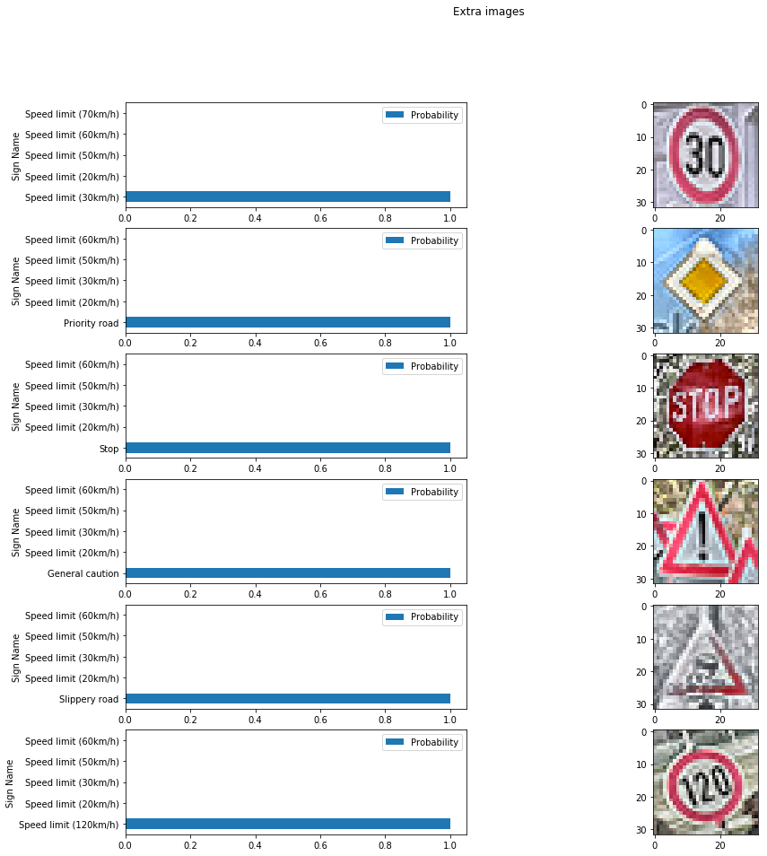

```python
sign_names = pd.read_csv('signnames.csv', index_col=0)
a = []
with tf.Session() as sess:
    saver.restore(sess, save_file)
    test_accuracy = evaluate(X_example, y_example)
    print('Test Accuracy is {:.2f}%'.format(test_accuracy*100))
    guess = sess.run(logits, feed_dict={x: X_example, keep_prob: 1.0})
    smax = tf.nn.softmax(guess)
    top_5 = sess.run(tf.nn.top_k(smax, k=5, sorted=True))
    fig = plt.figure(figsize=(15,15))
    fig.suptitle('Extra images')
    for i in range(6):
        df5 = pd.DataFrame({'Probability': top_5.values[i],
                            'Sign Name': sign_names['SignName'][top_5.indices[i]]})
        df5 = df5.set_index('Sign Name')
        print(df5, '\n')
        ax1 = plt.subplot(6,2,i*2+2)
        ax2 = plt.subplot(6,2,i*2+1)
        ax1.imshow(X_example[i])
        df5.plot.barh(ax=ax2)
    plt.show()
```

### Project Writeup

Once you have completed the code implementation, document your results in a project writeup using this [template](https://github.com/udacity/CarND-Traffic-Sign-Classifier-Project/blob/master/writeup_template.md) as a guide. The writeup can be in a markdown or pdf file.

## Step 4 (Optional): Visualize the Neural Network's State with Test Images

This Section is not required to complete but acts as an additional excersise for understaning the output of a neural network's weights. While neural networks can be a great learning device they are often referred to as a black box. We can understand what the weights of a neural network look like better by plotting their feature maps. After successfully training your neural network you can see what it's feature maps look like by plotting the output of the network's weight layers in response to a test stimuli image. From these plotted feature maps, it's possible to see what characteristics of an image the network finds interesting. For a sign, maybe the inner network feature maps react with high activation to the sign's boundary outline or to the contrast in the sign's painted symbol.

Provided for you below is the function code that allows you to get the visualization output of any tensorflow weight layer you want. The inputs to the function should be a stimuli image, one used during training or a new one you provided, and then the tensorflow variable name that represents the layer's state during the training process, for instance if you wanted to see what the LeNet lab's feature maps looked like for it's second convolutional layer you could enter conv2 as the tf_activation variable.

For an example of what feature map outputs look like, check out NVIDIA's results in their paper [End-to-End Deep Learning for Self-Driving Cars](https://devblogs.nvidia.com/parallelforall/deep-learning-self-driving-cars/) in the section Visualization of internal CNN State. NVIDIA was able to show that their network's inner weights had high activations to road boundary lines by comparing feature maps from an image with a clear path to one without. Try experimenting with a similar test to show that your trained network's weights are looking for interesting features, whether it's looking at differences in feature maps from images with or without a sign, or even what feature maps look like in a trained network vs a completely untrained one on the same sign image.

[figure not shown]

Your output should look something like this (above)

```python
### Visualize your network's feature maps here.
### Feel free to use as many code cells as needed.

# image_input: the test image being fed into the network to produce the feature maps
# tf_activation: should be a tf variable name used during your training procedure that represents the calculated state of a specific weight layer
# activation_min/max: can be used to view the activation contrast in more detail, by default matplot sets min and max to the actual min and max values of the output
# plt_num: used to plot out multiple different weight feature map sets on the same block, just extend the plt number for each new feature map entry

def outputFeatureMap(image_input, tf_activation, activation_min=-1, activation_max=-1 ,plt_num=1):
    # Here make sure to preprocess your image_input in a way your network expects
    # with size, normalization, ect if needed
    # image_input =
    # Note: x should be the same name as your network's tensorflow data placeholder variable
    # If you get an error tf_activation is not defined it may be having trouble accessing the variable from inside a function
    activation = tf_activation.eval(session=sess,feed_dict={x : image_input})
    featuremaps = activation.shape[3]
    plt.figure(plt_num, figsize=(15,15))
    for featuremap in range(featuremaps):
        plt.subplot(6,8, featuremap+1) # sets the number of feature maps to show on each row and column
        plt.title('FeatureMap ' + str(featuremap)) # displays the feature map number
        if activation_min != -1 & activation_max != -1:
            plt.imshow(activation[0,:,:, featuremap], interpolation="nearest", vmin =activation_min, vmax=activation_max, cmap="gray")
        elif activation_max != -1:
            plt.imshow(activation[0,:,:, featuremap], interpolation="nearest", vmax=activation_max, cmap="gray")
        elif activation_min !=-1:
            plt.imshow(activation[0,:,:, featuremap], interpolation="nearest", vmin=activation_min, cmap="gray")
        else:
            plt.imshow(activation[0,:,:, featuremap], interpolation="nearest", cmap="gray")
```